# Skagit Sockeye Forecast

Casey Ruff, modified original code from Thomas Buehrens

Last Updated 02/17/2022.

# Overview

This script fits log-normal Generalized Additive Models and ARIMA models to salmon run-size data with or without regression covariates. These models are then used to generate one-year-ahead forecasts. The data used to fit the models is split into “training” and “validation” sets to evaluate performance of the one-year-ahead forecasts, compare models, and develop weighted “ensemble” forecasts. The code repository used to generate this page and complete analyses can be found here: [**(link)**](https://github.com/tbuehrens/Salmon_Forecast_Example)

# Setup

All analyses require R software [**(link)**](https://cran.r-project.org/) (v3.4.3) for data retrieval, data processing, and summarizing model results. Here we configure R to perform our analysis and generate our outputs

```r
options(width = 100)
knitr::opts_chunk$set(message = FALSE)
set.seed(123)
```

```r
wd_functions<-"functions"
sapply(FUN = source, paste(wd_functions, list.files(wd_functions), sep="/"))
```

Here we will load & install packages we need to use (needs internet connection if packages not already installed)

```r
packages_list<-c("readr"
                 ,"tidyverse"
                 ,"forecast"
                 ,"mgcv"
                 ,"ggplot2"
                 ,"MASS"
                 ,"RColorBrewer"
                 ,"kableExtra"
                 ,"gtools"
                 # ,"ggfortify"
                 ,"lubridate"
                 #,"brms"
                 ,"here"
                 # ,"rnoaa"
                 # ,"ncdf4"
                 # ,"ncdf4.helpers"
                 # ,"raster"
                 # ,"reshape2"
                 # ,"ggfortify"
                 #
                 )
install_or_load_pack(pack = packages_list)

## set data dir
datadir <- here("data")
```

# Load Data

Here we will load and format our data for analysis. First, we will load and format our fish data for analysis. What you load is what you will forecast (so you can forecast run size or escapement)

```r
#====================================
#get Skagit Sockeye data as example
#====================================

dat <- read_csv(file.path(datadir, "baker_sockeye_SAR.csv"))

Yrlist<-data.frame(Year=c(min(dat$Year):(max(dat$Year) + 1)))


dat<-dat%>%
  right_join(Yrlist)

#look at our data
print(tail(data.frame(dat)))
```

```
##    Year  smolts runsize_obs Total_Recruits OA1_Recruits OA2_Recruits OA3_Recruits  Total_SAR
## 26 2017 1094898       33359       20011.95     91.16471     15303.41     4617.379 0.01827745
## 27 2018  850044       30996       20392.90      0.00000     14691.66     5701.239 0.02399040
## 28 2019  760016       22445             NA     69.96029     24230.27           NA         NA
## 29 2020  856688       19379             NA   1504.49370           NA           NA         NA
## 30 2021      NA       31436             NA           NA           NA           NA         NA
## 31 2022      NA          NA             NA           NA           NA           NA         NA
##       OA2_SAR     OA3_SAR
## 26 0.01397702 0.004217176
## 27 0.01728341 0.006706993
## 28 0.03188126          NA
## 29         NA          NA
## 30         NA          NA
## 31         NA          NA
```

The section will (optionally) download from the web (or load from the data folder) NOAA Ocean Indicator data, NOAA Ocean Buoy SST data, and NOAA smoothed modeled SST data (ERSST_V5), flow data, PIT tag data, or any other covariate data not included with the fish data that could assist in forecasting.

```r
#=========================================================
#get NPGO data
#=========================================================
NPGO<-read_table("http://www.o3d.org/npgo/npgo.php",skip=29,col_names=F,comment="#")%>%
  filter(!is.na(X2))%>%
  dplyr::rename(Year=X1,Month=X2,NPGO=X3)%>%
  mutate(Year=as.numeric(Year))%>%
  group_by(Year)%>%
  add_tally()%>%
  filter(Month == 2) #use only December NPGO
  #filter(!n < 12)%>% #use only complete years
  #group_by(Year)%>%
  #dplyr::summarise(NPGO=mean(NPGO))

 NPGO <- NPGO[which(NPGO$Year %in% Yrlist$Year),]

#=========================================================
#get NOAA indicator data, wrangle into usable format, plot
#=========================================================
#indicators<-read_csv("https://media.fisheries.noaa.gov/2021-04/Stoplight%20csv.csv?null",skip=1)%>%
indicators<-read_csv("data/Stoplight csv.csv",skip=1)%>%
  filter(!is.na(`Ecosystem Indicators`))%>%
  pivot_longer(names_to = "Year",
                cols=c(starts_with("1"),starts_with("2")),
                values_to = "value")%>%
  pivot_wider(names_from=`Ecosystem Indicators`,values_from=value)%>%
  mutate(Year=as.numeric(Year))

# plotdat<-indicators%>%pivot_longer(names_to = "indicators", cols = colnames(indicators)[colnames(indicators)!="Year"])
# ggplot(plotdat,aes(x=value,color=indicators))+
#   geom_density()+
#   facet_wrap(~indicators,scales="free")+
#   theme(legend.position = "none")

#==============================================================
# get NOAA sst data directly from Buoys (takes a while to run)
#==============================================================
# buoylist<-c(46229, 46211, 46041, 46029, 46050, 46097, 46098)
# years<-c(1980:2021)
# buoy_stations()%>%filter(lat > 44 & lat < 52 & lon > -130 & lon < -120)
# buoydat<-getbuoydata(buoylist = buoylist,years=years)
# write.csv(dat,"SST.csv",row.names = F)

#===================
#Plot Buoy SST data
#====================
# buoydat<-buoydat%>%
#   filter(!is.na(buoyid) & !is.na(meanSST))%>%
#   group_by(buoyid,month)%>%
#   mutate(gmeanSST=mean(meanSST),resid=meanSST-gmeanSST)
#
#
# ggplot(buoydat,aes(x=month,y=resid,group=factor(buoyid),color=factor(buoyid)))+
#   geom_hline(yintercept=0,linetype="dashed")+
#   scale_color_brewer(palette = "Spectral")+
#   geom_line()+
# facet_wrap(~factor(year))


#===========================================================================================================
#Get ERSST data: get_ersst_v5_data takes A LONG TIME (1 hr) vs. get_ersst_v5_data_V2 which is much quicker!
#===========================================================================================================
#dat<-get_ersst_v5_data(years=years,data.dir=getwd(),latrange=c(44,52),lonrange=c(-130,-120))
# data.dir<-"C:/Users/buehrtwb/OneDrive - Washington State Executive Branch Agencies/Documents"
# sstdat<-get_ersst_v5_data_V2(years=c(1980:2021),data.dir=data.dir ,ncfilename="SSTv5.nc",latrange=c(44,50),lonrange=c(-125,-120))
#
# sstdat<-sstdat%>%
#   mutate(sstdiff=c(NA,diff(resid)))
#
# #================
# #Plot ERSST data
# #================
# ggplot(sstdat,aes(x=factor(month),y=meanSST,group=year))+
#   geom_hline(yintercept=0,linetype="dashed")+
#   scale_color_brewer(palette = "Spectral")+
#   geom_line()+
#   facet_wrap(~factor(year))
#
# ggplot(sstdat,aes(x=factor(month),y=resid,group=year))+
#   geom_hline(yintercept=0,linetype="dashed")+
#   scale_color_brewer(palette = "Spectral")+
#   geom_line()+
#   facet_wrap(~factor(year))
#
# ggplot(sstdat,aes(x=factor(month),y=sstdiff,group=year))+
#   geom_hline(yintercept=0,linetype="dashed")+
#   scale_color_brewer(palette = "Spectral")+
#   geom_line()+
#   facet_wrap(~factor(year))
#
# ssta<-sstdat%>%
#   dplyr::select(year,month,resid)%>%
#   mutate(month = paste0("m_",month))%>%
#   rename(Year = year)%>%
#   pivot_wider(names_from = month,values_from = resid)
#
# pcdat<-ssta%>%
#   ungroup()%>%
#   filter(Year<2021)%>%
#   column_to_rownames(var="Year")
# mod<-prcomp(pcdat
#             )
# autoplot(mod,data=ssta%>%filter(Year<2021)%>%column_to_rownames(var="Year"),
#          x=1,
#          y=3,
#          label = TRUE,
#          label.size = 3,
#          shape=F)
```

If we loaded/downloaded covariate data (other than fish abundance) for use in forecasting, in this section we will merge it with our fish data to produce a final dataframe. Note the format below; the rest of the functions and sections rely on your data being formatted this way,

```r
dat<-dat%>%
  #left_join(PIT)%>%
  left_join(NPGO)%>%
  #left_join(indicators)%>%
  #left_join(ssta)%>%
  mutate(
    # l1aprssta= lag(scale(m_04)),
    # l1mayssta= lag(scale(m_05)),
    # l1junssta= lag(scale(m_06)),
    # l1julssta= lag(scale(m_07)),
    # l1augssta= lag(scale(m_08)),
    # l1sepssta= lag(scale(m_09)),
    # l1octssta= lag(scale(m_10)),
    # l1novssta= lag(scale(m_11)),
    # l1decssta= lag(scale(m_12)),
    # l1FallSST= (lag(scale(m_10)) + lag(scale(m_11)) + lag(scale(m_12)))/3
    # PC1 = lag(mod$x[,1]),
    # PC2 = lag(mod$x[,2]),
    # PC3 = lag(mod$x[,3]),
    # lag1_summerPDO = lag(scale(`PDO\n(Sum May-Sept)`)),
    # lag1_springONI = lag(scale(`ONI\n(Average Jan-June)`)),
    # lag1_summerdeepSST = lag(scale(`Deep temperature\n(°C; May-Sept)`)),
    # lag1_summerdeepSalinity = lag(scale(`Deep salinity\n(May-Sept)`)),
    # lag1_copepodrich = lag(scale(`Deep salinity\n(May-Sept)`)),
    # lag1_icthy = lag(scale(`Nearshore Ichthyoplankton\nLog(mg C 1,000 m-3; Jan-Mar)`)),
    # lag1_cpueCO = lag(scale(log(`Steelhead salmon juvenile\ncatches (no. km-1; June)`))),
    # lag1_phystrans = lag (scale(`Physical Spring Trans.\nUI based (day of year)`)),
    # lag1_Ncope = lag(scale(`N. copepod biomass anom.\n(mg C m-3; May-Sept)`)),
    # lag1_summerSST=lag(scale(`Upper 20 m T\n(°C; May-Sept)`)),
    lag2_NPGO = lag(NPGO,2),
    lag3_NPGO = lag(NPGO,3),
    lag2_smolts = lag(smolts,2),
    lag3_smolts = lag(smolts,3)
    )



#select variables to include in analysis and subset data
vars<-c("lag2_NPGO","lag3_NPGO","lag2_smolts","lag3_smolts")#,"lag2_PC1","lag2_PC2","lag1_NPGO") #what regression variables will we use?
dat<-data.frame(dat)%>%
  dplyr::select(Year,runsize_obs,all_of(vars))%>%
  filter(
    across(
      .cols = all_of(vars),
      .fns = ~ !is.na(.x)
    )
  )

sockeye_cov <- data.frame(dat[,c(1,5:6)])
 pcdat<-sockeye_cov%>%
   ungroup()%>%
   column_to_rownames(var="Year")
 mod<-prcomp(pcdat
             )
dat <- data.frame(dat,PC1_smolts = mod$x[,1],PC2_smolts = mod$x[,2])

#look at our data
print(data.frame(dat))
```

```
##      Year runsize_obs  lag2_NPGO  lag3_NPGO lag2_smolts lag3_smolts PC1_smolts PC2_smolts
## 1995 1995        2208 -2.1408178 -0.4565314       25848       90238 -433005.59   57338.16
## 1996 1996        7775 -1.9786652 -2.1408178      147512       25848 -390216.89  -73495.05
## 1997 1997        7250 -1.5608722 -1.9786652      151104      147512 -303118.10   11527.49
## 1998 1998       13406 -1.0529048 -1.5608722      190540      151104 -272255.01  -13283.19
## 1999 1999        4667 -1.1130951 -1.0529048      120376      190540 -295332.21   63824.70
## 2000 2000       10811  1.9000587 -1.1130951       92499      120376 -364125.26   32717.94
## 2001 2001        5042  2.3041594  1.9000587      193234       92499 -311027.56  -57311.51
## 2002 2002        4036  2.1235311  2.3041594       28325      193234 -359676.75  129706.61
## 2003 2003       20977  2.9560468  2.1235311      194955       28325 -354368.59 -104669.93
## 2004 2004       11309  2.1773568  2.9560468      149481      194955 -271328.91   46782.56
## 2005 2005        3587  0.9925656  2.1773568       70826      149481 -359497.48   68709.66
## 2006 2006        9828  0.6672296  0.9925656      170820       70826 -342206.17  -57331.69
## 2007 2007        3720 -1.4951167  0.6672296      117083      170820 -311399.66   51926.83
## 2008 2008        5763 -1.0768154 -1.4951167      289304      117083 -224843.11 -106363.09
## 2009 2009        6727 -0.1306720 -1.0768154      158264      289304 -199470.62  108550.36
## 2010 2010       22778  1.1404093 -0.1306720      253004      158264 -222348.41  -51523.86
## 2011 2011       37057  0.9347976  1.1404093      342941      253004  -91841.22  -45849.11
## 2012 2012       47971  1.8289311  0.9347976      436587      342941   37997.57  -46205.83
## 2013 2013       17804  0.5667173  1.8289311      209508      436587  -60297.40  178899.80
## 2014 2014       27143  0.8644039  0.5667173      469932      209508  -30706.40 -165352.87
## 2015 2015       51074  1.2154312  0.8644039      758309      469932  357640.36 -178343.04
## 2016 2016       42910 -0.2566992  1.2154312      939879      758309  688574.39  -97031.13
## 2017 2017       33359 -1.2894633 -0.2566992      700757      939879  642693.56  199687.50
## 2018 2018       30996  0.2150629 -1.2894633      787650      700757  539091.04  -32683.41
## 2019 2019       22445 -0.6647293  0.2150629     1094898      787650  820467.70 -183610.23
## 2020 2020       19379 -2.2272986 -0.6647293      850044     1094898  857766.88  207495.36
## 2021 2021       31436 -2.5614696 -2.2272986      760016      850044  622916.27   93900.85
## 2022 2022          NA -2.3216707 -2.5614696      856688      760016  629917.58  -38013.89
```

# Set Parameters

Here we specify parameters for our forecast training and evaluation: how many years of training data to include in the training set (validation is the rest), how many years forward to forecast (typically 1), and make some selections regarding which metric to use to evaluate forecast odel performance.

```r
#set model fitting and evaluation params
TY <- dim(dat)[1]-12 #training years (years of training data)
FY <- 1 #forecast years (years foreward to forecast)
k = 1 #this is the model-averaging weighting exponent--default is 1, larger numbers will tend to more heavily weight "best" models over lower ranked models
stack_metric = "MSA" #this is the performance measure that will be optimized to find the best stack weights
```

# Fit Forecast Models

Here we fit ARIMA and GAM forecasts

```r
#==========
#ARIMA models
#==========
ARIMA100<-tsCV2(y=log(dat$runsize_obs[-dim(dat)[1]]),
            Year=dat$Year,
            xreg=NULL,
            h=FY,
            min=TY,
            type="ARIMA",
            order=c(1,0,0)
)
ARIMA100_withcov_NPGO_smolts<-tsCV2(y=log(dat$runsize_obs[-dim(dat)[1]]),
            Year=dat$Year,
            xreg=dat%>%dplyr::select("lag2_NPGO","lag3_NPGO","lag2_smolts","lag3_smolts")%>%as.matrix(),
            h=FY,
            min=TY,
            type="ARIMA",
            order=c(1,0,0)
      )

ARIMA100_withcov_NPGO<-tsCV2(y=log(dat$runsize_obs[-dim(dat)[1]]),
            Year=dat$Year,
            xreg=dat%>%dplyr::select("lag2_NPGO","lag3_NPGO")%>%as.matrix(),
            h=FY,
            min=TY,
            type="ARIMA",
            order=c(1,0,0)
      )

ARIMA100_withcov_smolts<-tsCV2(y=log(dat$runsize_obs[-dim(dat)[1]]),
            Year=dat$Year,
            xreg=dat%>%dplyr::select("lag2_smolts","lag3_smolts")%>%as.matrix(),
            h=FY,
            min=TY,
            type="ARIMA",
            order=c(1,0,0)
      )

ARIMA111_withcov_NPGO_smolts<-tsCV2(y=log(dat$runsize_obs[-dim(dat)[1]]),
            Year=dat$Year,
            xreg=dat%>%dplyr::select("lag2_NPGO","lag3_NPGO","lag2_smolts","lag3_smolts")%>%as.matrix(),
            h=FY,
            min=TY,
            type="ARIMA",
            order=c(1,1,1)
)

ARIMA111_withcov_NPGO<-tsCV2(y=log(dat$runsize_obs[-dim(dat)[1]]),
            Year=dat$Year,
            xreg=dat%>%dplyr::select("lag2_NPGO","lag3_NPGO")%>%as.matrix(),
            h=FY,
            min=TY,
            type="ARIMA",
            order=c(1,1,1)
)


ARIMA111_withcov_smolts<-tsCV2(y=log(dat$runsize_obs[-dim(dat)[1]]),
            Year=dat$Year,
            xreg=dat%>%dplyr::select("lag2_smolts","lag3_smolts")%>%as.matrix(),
            h=FY,
            min=TY,
            type="ARIMA",
            order=c(1,1,1)
)

ARIMA010_withcov_NPGO_smolts<-tsCV2(y=log(dat$runsize_obs[-dim(dat)[1]]),
            Year=dat$Year,
            xreg=dat%>%dplyr::select("lag2_NPGO","lag3_NPGO","lag2_smolts","lag3_smolts")%>%as.matrix(),
            h=FY,
            min=TY,
            type="ARIMA",
            order=c(0,1,0)
)

ARIMA010_withcov_NPGO<-tsCV2(y=log(dat$runsize_obs[-dim(dat)[1]]),
            Year=dat$Year,
            xreg=dat%>%dplyr::select("lag2_NPGO","lag3_NPGO")%>%as.matrix(),
            h=FY,
            min=TY,
            type="ARIMA",
            order=c(0,1,0)
)

ARIMA010_withcov_smolts<-tsCV2(y=log(dat$runsize_obs[-dim(dat)[1]]),
            Year=dat$Year,
            xreg=dat%>%dplyr::select("lag2_smolts","lag3_smolts")%>%as.matrix(),
            h=FY,
            min=TY,
            type="ARIMA",
            order=c(0,1,0)
)

ARIMA010<-tsCV2(y=log(dat$runsize_obs[-dim(dat)[1]]),
            Year=dat$Year,
            xreg=NULL,
            h=FY,
            min=TY,
            type="ARIMA",
            order=c(0,1,0)
)
# ARIMA111<-tsCV2(y=log(dat$runsize_obs[-dim(dat)[1]]),
#             Year=dat$Year,
#             xreg=NULL,
#             h=FY,
#             min=TY,
#             type="ARIMA",
#             order=c(1,1,1)
# )
ARIMA101_withcov_NPGO_smolts<-tsCV2(y=log(dat$runsize_obs[-dim(dat)[1]]),
            Year=dat$Year,
            xreg=dat%>%dplyr::select("lag2_NPGO","lag3_NPGO","lag2_smolts","lag3_smolts")%>%as.matrix(),
            h=FY,
            min=TY,
            type="ARIMA",
            order=c(1,0,1)
)

ARIMA101_withcov_NPGO<-tsCV2(y=log(dat$runsize_obs[-dim(dat)[1]]),
            Year=dat$Year,
            xreg=dat%>%dplyr::select("lag2_NPGO","lag3_NPGO")%>%as.matrix(),
            h=FY,
            min=TY,
            type="ARIMA",
            order=c(1,0,1)
)

ARIMA101_withcov_smolts<-tsCV2(y=log(dat$runsize_obs[-dim(dat)[1]]),
            Year=dat$Year,
            xreg=dat%>%dplyr::select("lag2_smolts","lag3_smolts")%>%as.matrix(),
            h=FY,
            min=TY,
            type="ARIMA",
            order=c(1,0,1)
)


ARIMA101<-tsCV2(y=log(dat$runsize_obs[-dim(dat)[1]]),
            Year=dat$Year,
            xreg=NULL,
            h=FY,
            min=TY,
            type="ARIMA",
            order=c(1,0,1)
)
ARIMA001_withcov_NPGO_smolts<-tsCV2(y=log(dat$runsize_obs[-dim(dat)[1]]),
            Year=dat$Year,
            xreg=dat%>%dplyr::select("lag2_NPGO","lag3_NPGO","lag2_smolts","lag3_smolts")%>%as.matrix(),
            h=FY,
            min=TY,
            type="ARIMA",
            order=c(0,0,1)
)

ARIMA001_withcov_NPGO<-tsCV2(y=log(dat$runsize_obs[-dim(dat)[1]]),
            Year=dat$Year,
            xreg=dat%>%dplyr::select("lag2_NPGO","lag3_NPGO")%>%as.matrix(),
            h=FY,
            min=TY,
            type="ARIMA",
            order=c(0,0,1)
)

ARIMA001_withcov_smolts<-tsCV2(y=log(dat$runsize_obs[-dim(dat)[1]]),
            Year=dat$Year,
            xreg=dat%>%dplyr::select("lag2_smolts","lag3_smolts")%>%as.matrix(),
            h=FY,
            min=TY,
            type="ARIMA",
            order=c(0,0,1)
)

ARIMA001<-tsCV2(y=log(dat$runsize_obs[-dim(dat)[1]]),
            Year=dat$Year,
            xreg=NULL,
            h=FY,
            min=TY,
            type="ARIMA",
            order=c(0,0,1)
)
#==========
#GAM models
#==========
gam<-tsCV2(y=log(dat$runsize_obs[-dim(dat)[1]]),
            Year=dat$Year,
            xreg=NULL,
            h=FY,
            min=TY,
            type="gam",
            m=1,
            knots=dim(dat)[1]-1
)
# LFO10<-tsCV2(y=log(dat$runsize_obs[-dim(dat)[1]]),
#             Year=dat$Year,
#             xreg=dat%>%dplyr::select(all_of(vars))%>%as.matrix(),
#             h=FY,
#             min=TY,
#             type="gam"
#             m=1,
#             knots=dim(dat)[1]-1
# )
#================================
#BRMS models with Horseshoe Prior
#================================
# gp_horseshoe<-fc3(
#   Year=dat$Year,
#   TY=TY
#   ,vars=vars
#   ,dat=dat
#   ,formula = as.formula(paste0("log(runsize_obs) ~ gp(Year) + ",paste(vars,collapse = "+")))
#   ,prior = set_prior(horseshoe(df = 1, par_ratio = 0.5), class="b")
# )
# LFO12<-fc3(
#   Year=dat$Year,
#   TY=TY
#   ,vars=vars
#   ,dat=dat
#   ,formula = as.formula(paste0("log(runsize_obs) ~ arma(p = 1, q = 1, cov=TRUE) + ",paste(vars,collapse = "+")))
#   ,prior = set_prior(horseshoe(df = 1, par_ratio = 0.5), class="b")
# )
```

# Summarize Forecasts

```r
#===================
#Summarize Forecasts
#===================
forecasts<-summarize_forecasts(
   c("ARIMA100",
    "ARIMA100_withcov_NPGO_smolts",
    "ARIMA100_withcov_NPGO",
    "ARIMA100_withcov_smolts",
    "ARIMA111_withcov_NPGO_smolts",
    "ARIMA111_withcov_NPGO",
    "ARIMA111_withcov_smolts",
    "ARIMA010_withcov_NPGO_smolts",
    "ARIMA010_withcov_NPGO",
    "ARIMA010_withcov_smolts"
    ,"ARIMA010"
    #,"ARIMA111"
    ,"ARIMA101_withcov_NPGO_smolts",
    "ARIMA101_withcov_NPGO",
    "ARIMA101_withcov_smolts"
    ,"ARIMA101"
    ,"ARIMA001_withcov_NPGO_smolts",
    "ARIMA001_withcov_NPGO",
    "ARIMA001_withcov_smolts"
    ,"ARIMA001"
    ,"gam"
    # LFO10
    #,"gp_horseshoe"
    #LFO12
    )
)
#========================================
#Table of forecast results for final year
#========================================
forecasts%>%
  group_by(Model)%>%
  filter(Year==max(Year,na.rm = T))%>%
  kbl(caption = "Table 1. Forecasts for final year of data.",digits =0)%>%
  kable_classic(full_width = F, html_font = "Cambria")
```

Table 1. Forecasts for final year of data.

| Model | Year | Estimate | L95 | U95 |
| --- | --- | --- | --- | --- |
| ARIMA100 | 2022 | 22890 | 5523 | 94865 |
| ARIMA100_withcov_NPGO_smolts | 2022 | 37234 | 14010 | 98956 |
| ARIMA100_withcov_NPGO | 2022 | 29158 | 9030 | 94152 |
| ARIMA100_withcov_smolts | 2022 | 38411 | 11851 | 124502 |
| ARIMA111_withcov_NPGO_smolts | 2022 | 37878 | 13668 | 104968 |
| ARIMA111_withcov_NPGO | 2022 | 33388 | 10252 | 108737 |
| ARIMA111_withcov_smolts | 2022 | 38420 | 11295 | 130681 |
| ARIMA010_withcov_NPGO_smolts | 2022 | 42368 | 14174 | 126642 |
| ARIMA010_withcov_NPGO | 2022 | 37071 | 11471 | 119802 |
| ARIMA010_withcov_smolts | 2022 | 42279 | 11346 | 157548 |
| ARIMA010 | 2022 | 31436 | 7158 | 138059 |
| ARIMA101_withcov_NPGO_smolts | 2022 | 39943 | 15210 | 104897 |
| ARIMA101_withcov_NPGO | 2022 | 29203 | 8816 | 96736 |
| ARIMA101_withcov_smolts | 2022 | 39246 | 11803 | 130496 |
| ARIMA101 | 2022 | 22883 | 5652 | 92643 |
| ARIMA001_withcov_NPGO_smolts | 2022 | 39064 | 15111 | 100986 |
| ARIMA001_withcov_NPGO | 2022 | 27502 | 7064 | 107064 |
| ARIMA001_withcov_smolts | 2022 | 39250 | 12015 | 128227 |
| ARIMA001 | 2022 | 18259 | 3754 | 88807 |
| gam | 2022 | 27362 | 14175 | 52818 |

# Evaluate Forecasts

Here we will evaluate forecasts using Mean Absolute Percent Error (MAPE), Root Mean Squared Error (RMSE), and Median Symmetric Accuracy (MSA). RMSE and MAPE tend to more heavily penalize over-forecasts relative to under-forecasts for abundance (because errors are right-skewed), whereas MSA is specifically tailored for right tailed distributions. We will also calculated model weights

```r
forecast_skill<-evaluate_forecasts(forecasts=forecasts,observations=dat)

forecasts[which(forecasts$Model %in% forecast_skill$Model[1:10]),]
```

```
## # A tibble: 120 x 5
##    Model                         Year Estimate    L95     U95
##    <chr>                        <dbl>    <dbl>  <dbl>   <dbl>
##  1 ARIMA111_withcov_NPGO_smolts  2011   15727.  5685.  43504.
##  2 ARIMA111_withcov_NPGO_smolts  2012   61656. 21788. 174469.
##  3 ARIMA111_withcov_NPGO_smolts  2013    8811.  3264.  23787.
##  4 ARIMA111_withcov_NPGO_smolts  2014   49812. 18358. 135156.
##  5 ARIMA111_withcov_NPGO_smolts  2015  176229. 65160. 476619.
##  6 ARIMA111_withcov_NPGO_smolts  2016   57980. 20731. 162162.
##  7 ARIMA111_withcov_NPGO_smolts  2017   20759.  7643.  56384.
##  8 ARIMA111_withcov_NPGO_smolts  2018   80503. 30231. 214374.
##  9 ARIMA111_withcov_NPGO_smolts  2019   53999. 19263. 151377.
## 10 ARIMA111_withcov_NPGO_smolts  2020   13385.  4690.  38202.
## # ... with 110 more rows
```

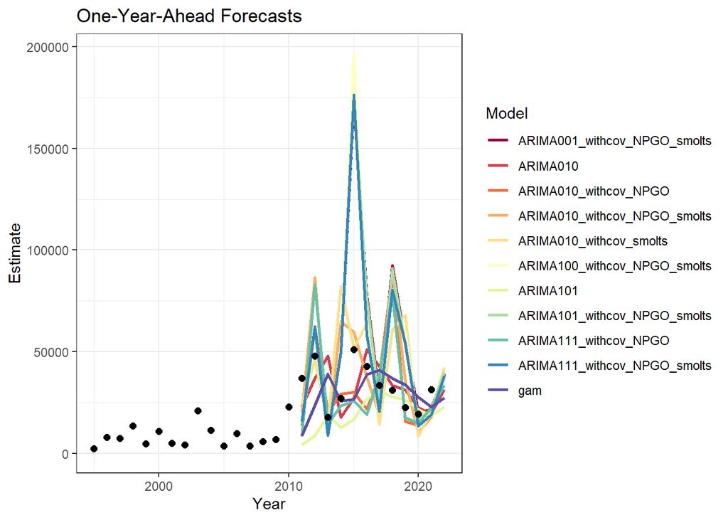

```r
#===========================
#Plot of final year forecast
#===========================
ggplot(data=forecasts[which(forecasts$Model %in% forecast_skill$Model[1:11]),],aes(x=Year,y=Estimate,color=Model))+
  labs(title="One-Year-Ahead Forecasts")+
  geom_line(size=1)+
  scale_color_brewer(palette="Spectral")+
  geom_point(data=dat,mapping=aes(x=Year,y=runsize_obs),size=2,color="black")+
  ylim(0,NA)+
  theme_bw()
```

```r
#=======================
#Table of Forecast Skill
#=======================
forecast_skill%>%
  kbl(caption = "Table 2.Forecast Performance based on full set of one-year-ahead forecasts.",digits =3)%>%
  kable_classic(full_width = F, html_font = "Cambria")
```

Table 2.Forecast Performance based on full set of one-year-ahead forecasts.

| Model | RMSE | MAPE | MSA |
| --- | --- | --- | --- |
| ARIMA010 | 14410.57 | 41.776 | 47.064 |
| ARIMA010_withcov_NPGO | 21575.41 | 44.317 | 55.367 |
| gam | 16037.97 | 42.755 | 60.488 |
| ARIMA111_withcov_NPGO | 22788.29 | 48.454 | 70.528 |
| ARIMA010_withcov_smolts | 25495.11 | 68.308 | 72.816 |
| ARIMA010_withcov_NPGO_smolts | 26348.75 | 65.795 | 76.279 |
| ARIMA001_withcov_NPGO_smolts | 44885.64 | 84.951 | 86.596 |
| ARIMA101_withcov_NPGO_smolts | 44853.18 | 85.497 | 89.879 |
| ARIMA111_withcov_NPGO_smolts | 43611.40 | 82.595 | 91.266 |
| ARIMA101 | 20195.00 | 38.457 | 93.985 |
| ARIMA100_withcov_NPGO_smolts | 49657.47 | 89.076 | 94.740 |
| ARIMA100_withcov_NPGO | 20507.86 | 51.102 | 95.590 |
| ARIMA100 | 20843.78 | 41.226 | 101.455 |
| ARIMA001_withcov_smolts | 82708.27 | 133.067 | 105.064 |
| ARIMA111_withcov_smolts | 72984.09 | 122.636 | 110.578 |
| ARIMA100_withcov_smolts | 81046.57 | 131.773 | 111.776 |
| ARIMA101_withcov_smolts | 77512.21 | 131.057 | 115.254 |
| ARIMA101_withcov_NPGO | 20730.09 | 54.668 | 119.901 |
| ARIMA001_withcov_NPGO | 19997.20 | 52.214 | 127.518 |
| ARIMA001 | 23298.37 | 55.506 | 157.656 |

# Ensembles & Ensemble Performance

Calculate leave-forward-out performance year by year in order to develop weighted ensembles (with recalculated weights each year). Then evaluate performance of these one-year-ahead ensembles and compare with original models. Note that one fewer years of leave-forward-out forecasts is evaluated since an ensemble using previous years’ forecast skill can only be created for the second through last years of leave-forward-out forecasts.

```r
ensemble_results<-evaluate_forecasts_with_ensembles(forecasts = forecasts, observations = dat)
#=================================
#Table of final year model weights
#=================================
ensemble_results$final_model_weights%>%
  dplyr::select(Model, RMSE_weight, MAPE_weight, MSA_weight, Stacking_weight)%>%
  kbl(caption = "Table 3. Final Year Model Weights based on full dataset of one-year-ahead performance.",digits =3)%>%
  kable_classic(full_width = F, html_font = "Cambria")
```

Table 3. Final Year Model Weights based on full dataset of one-year-ahead performance.

| Model | RMSE_weight | MAPE_weight | MSA_weight | Stacking_weight |
| --- | --- | --- | --- | --- |
| ARIMA010 | 0.096 | 0.074 | 0.092 | 0.444 |
| ARIMA010_withcov_NPGO | 0.064 | 0.070 | 0.078 | 0.000 |
| gam | 0.086 | 0.072 | 0.072 | 0.000 |
| ARIMA111_withcov_NPGO | 0.061 | 0.064 | 0.061 | 0.000 |
| ARIMA010_withcov_smolts | 0.054 | 0.045 | 0.060 | 0.000 |
| ARIMA010_withcov_NPGO_smolts | 0.052 | 0.047 | 0.057 | 0.000 |
| ARIMA001_withcov_NPGO_smolts | 0.031 | 0.036 | 0.050 | 0.201 |
| ARIMA101_withcov_NPGO_smolts | 0.031 | 0.036 | 0.048 | 0.000 |
| ARIMA111_withcov_NPGO_smolts | 0.032 | 0.037 | 0.047 | 0.000 |
| ARIMA101 | 0.068 | 0.080 | 0.046 | 0.000 |
| ARIMA100_withcov_NPGO_smolts | 0.028 | 0.035 | 0.046 | 0.000 |
| ARIMA100_withcov_NPGO | 0.067 | 0.061 | 0.045 | 0.000 |
| ARIMA100 | 0.066 | 0.075 | 0.043 | 0.000 |
| ARIMA001_withcov_smolts | 0.017 | 0.023 | 0.041 | 0.000 |
| ARIMA111_withcov_smolts | 0.019 | 0.025 | 0.039 | 0.000 |
| ARIMA100_withcov_smolts | 0.017 | 0.023 | 0.039 | 0.000 |
| ARIMA101_withcov_smolts | 0.018 | 0.024 | 0.038 | 0.000 |
| ARIMA101_withcov_NPGO | 0.067 | 0.057 | 0.036 | 0.000 |
| ARIMA001_withcov_NPGO | 0.069 | 0.059 | 0.034 | 0.355 |
| ARIMA001 | 0.059 | 0.056 | 0.027 | 0.000 |

```r
#=======================================
#Table of final year ensemable forecasts
#=======================================
ensemble_results$ensembles%>%
  group_by(Model)%>%
  filter(Year==max(Year,na.rm=T))%>%
  kbl(caption = "Table 4. Ensemble forecasts one year ahead of final year of data.",digits =0)%>%
  kable_classic(full_width = F, html_font = "Cambria")
```

Table 4. Ensemble forecasts one year ahead of final year of data.

| Year | Model | Estimate | L95 | U95 |
| --- | --- | --- | --- | --- |
| 2022 | MSA_weighted | 34056 | 10873 | 111079 |
| 2022 | RMSE_weighted | 31601 | 9844 | 106577 |
| 2022 | MAPE_weighted | 31837 | 9951 | 106569 |
| 2022 | Stack_weighted | 31575 | 8726 | 119593 |

```r
#=============================
#calc performance of ensembles
#=============================
ensemble_results$forecast_skill%>%
  kbl(caption = "Table 5. One-year ahead performance of model & model ensemble forecasts. Ensemble weights recalculated annually using weights based on one-head performance up to to and including the year prior to the forecast year. Year one of one-year ahead fits not included since an ensemble cannot be computed for this year.",digits =3)%>%
  kable_classic(full_width = F, html_font = "Cambria")
```

Table 5. One-year ahead performance of model & model ensemble forecasts. Ensemble weights recalculated annually using weights based on one-head performance up to to and including the year prior to the forecast year. Year one of one-year ahead fits not included since an ensemble cannot be computed for this year.

| Model | RMSE | MAPE | MSA |
| --- | --- | --- | --- |
| Stack_weighted | 6989.312 | 12.038 | 12.889 |
| RMSE_weighted | 10370.324 | 28.243 | 30.136 |
| MAPE_weighted | 12488.729 | 32.371 | 34.421 |
| ARIMA010 | 14423.663 | 42.101 | 45.587 |
| gam | 14239.825 | 39.390 | 45.636 |
| ARIMA010_withcov_NPGO | 21365.730 | 42.388 | 46.757 |
| MSA_weighted | 21302.442 | 48.362 | 48.295 |
| ARIMA111_withcov_NPGO | 22069.123 | 45.469 | 54.391 |
| ARIMA101 | 18460.189 | 33.440 | 66.787 |
| ARIMA010_withcov_smolts | 26446.145 | 71.768 | 75.182 |
| ARIMA010_withcov_NPGO_smolts | 27103.754 | 67.774 | 75.410 |
| ARIMA100 | 19366.248 | 36.694 | 76.799 |
| ARIMA100_withcov_NPGO | 19345.877 | 48.191 | 77.872 |
| ARIMA001_withcov_NPGO_smolts | 46580.618 | 87.631 | 82.036 |
| ARIMA101_withcov_NPGO_smolts | 46513.519 | 88.044 | 84.714 |
| ARIMA111_withcov_NPGO_smolts | 45239.954 | 85.099 | 87.318 |
| ARIMA100_withcov_NPGO_smolts | 51624.731 | 92.113 | 90.538 |
| ARIMA001_withcov_smolts | 86544.645 | 141.344 | 105.453 |
| ARIMA101_withcov_NPGO | 20113.038 | 53.089 | 110.615 |
| ARIMA111_withcov_smolts | 76345.327 | 130.169 | 112.779 |
| ARIMA100_withcov_smolts | 84802.952 | 139.984 | 113.138 |
| ARIMA101_withcov_smolts | 81012.913 | 138.383 | 113.199 |
| ARIMA001_withcov_NPGO | 19453.490 | 50.747 | 121.164 |
| ARIMA001 | 22094.983 | 52.151 | 127.021 |

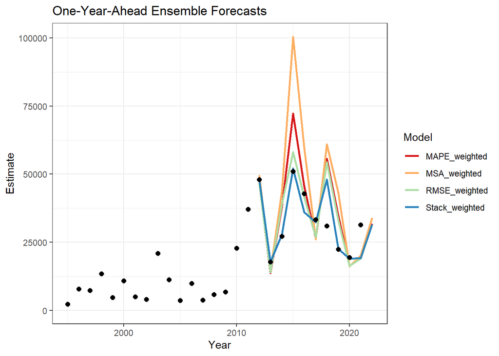

```r
#==============
#plot ensemble forecasts
#==============
ggplot(data=ensemble_results$ensembles,aes(x=Year,y=Estimate,color=Model))+
  labs(title="One-Year-Ahead Ensemble Forecasts")+
  geom_line(size=1)+
  scale_color_brewer(palette="Spectral")+
  geom_point(data=dat,mapping=aes(x=Year,y=runsize_obs),size=2,color="black")+
  ylim(0,NA)+
  theme_bw()
```

# Best Model

Identify the best model and plot and summarize its results

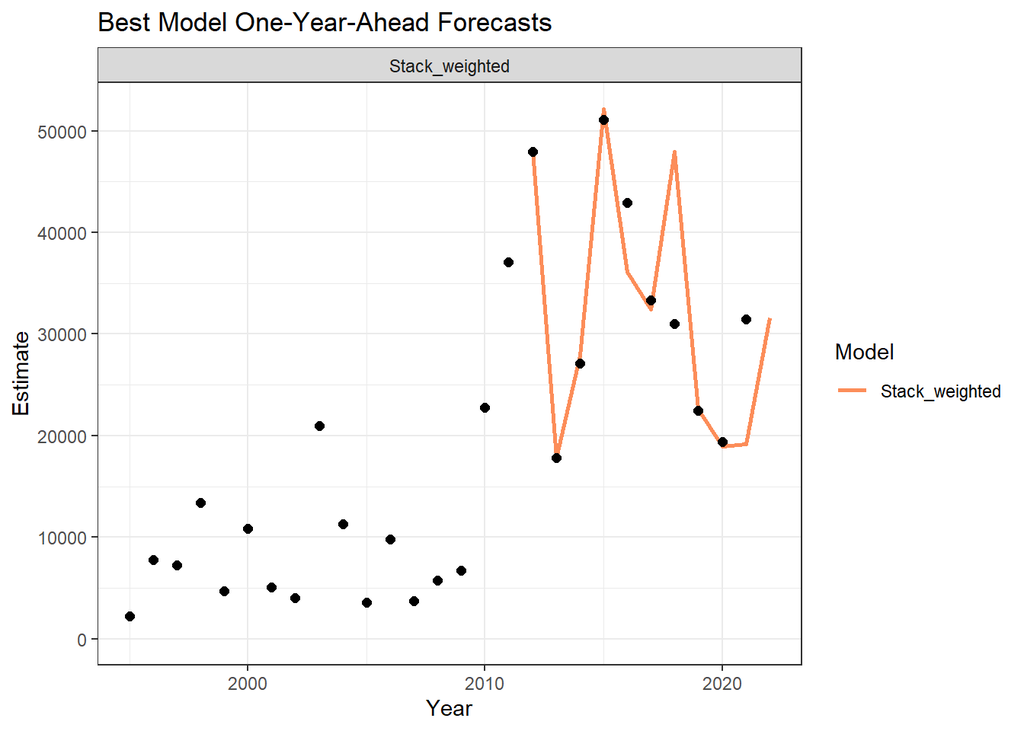

```r
best_model <- get_best_model(
  forecasts = forecasts
  ,ensembles = ensemble_results$ensembles
  ,stack_metric = stack_metric
  ,forecast_skill = ensemble_results$forecast_skill
)

#==============
#plot Best Model
#==============
ggplot(data=best_model,aes(x=Year,y=Estimate,color=Model))+
  #geom_ribbon(aes(ymin=L95,ymax=U95,,fill=Model),color=NA,alpha=0.4)+
  facet_wrap(~Model,ncol=1)+
  labs(title="Best Model One-Year-Ahead Forecasts")+
  geom_line(size=1)+
  scale_color_brewer(palette="Spectral")+
  geom_point(data=dat,mapping=aes(x=Year,y=runsize_obs),size=2,color="black")+
  ylim(0,NA)+
  theme_bw()
```

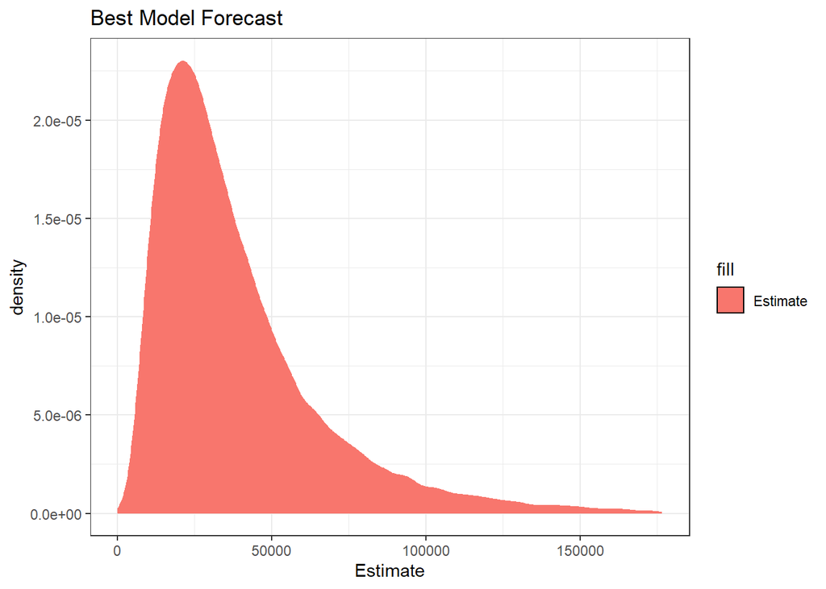

```r
best_mu<-log(best_model%>%filter(Year==max(Year))%>%dplyr::select(Estimate))%>%unlist()
best_sd<-best_model%>%filter(Year==max(Year))%>%dplyr::select(sd)%>%unlist()
best_draws=data.frame(Estimate=rlnorm(25000,mean=best_mu,sd=best_sd[1]))

#=========================
#Best model final year pdf
#=========================
ggplot(data=best_draws,aes(x=Estimate,color=NA),alpha=0.4)+
  geom_density(aes(fill="Estimate"))+
  xlim(0,quantile(best_draws$Estimate,0.995))+
  labs(title="Best Model Forecast")+
  scale_color_brewer(palette="Spectral")+
  ylim(0,NA)+
  theme_bw()
```

```r
#===========================
#Best Model final year table
#===========================
best_model%>%
  group_by(Model)%>%
  filter(Year==max(Year,na.rm=T))%>%
  dplyr::select(Model,Year,Estimate,L95,U95)%>%
  kbl(caption = "Table 5. Best model forecasts one year ahead of final year of data.",digits =0)%>%
  kable_classic(full_width = F, html_font = "Cambria")
```

Table 5. Best model forecasts one year ahead of final year of data.

| Model | Year | Estimate | L95 | U95 |
| --- | --- | --- | --- | --- |
| Stack_weighted | 2022 | 31575 | 8726 | 119593 |